# Spliceosome analysis with genes from TCGA - 404 splicing factor genes

Description: exploration of the mutations in the spliceosome on the cell lines studied by DepMap. Spliceosome genes considered were the same ones under study by TCGA.

Load libraries

```r
library(tidyverse)
library(data.table)
library(biomaRt)
library(readxl)
library(RColorBrewer)
library(ggrepel)
library(tidyHeatmap)
rename = dplyr::rename
select = dplyr::select
```

Load data

```r
splicing_factors <- read_excel("spliceosome/TCGA_spliceosome.xlsx")
CCLE_mutations = fread("depmap/ccle_info_21q1.csv", header = TRUE) #mutations and sample info
```

```
|--------------------------------------------------|
|==================================================|
|--------------------------------------------------|
|==================================================|
```

```r
head(splicing_factors)
```

| Entrez Gene ID | Gene Symbol | TCGA MC3-gene | Recommended for final inclusion | Functional Group -Barbosa | Gene Symbol -Barbosa | Description -Barbosa | SwissProt Accession -Barbosa | Name -Hegele | Gene Symbol -Hegele | SP_ID Hegele | Category Hegele | Group_short Hegele | Gene Symbol - SpliceosomeDB | Complex -SpliceosomeDB | Class / family -SpliceosomeDB | Pdbs -SpliceosomeDB | additional comment | Consensus group | Final 119 and reason for inclusion | MutSigCV significant cohorts | hotspot or LoF identified | Hotspot vs. LoF cohorts | High mutation rate tumor only | 2020+ significant cohorts |
| --- | --- | --- | --- | --- | --- | --- | --- | --- | --- | --- | --- | --- | --- | --- | --- | --- | --- | --- | --- | --- | --- | --- | --- | --- |
| 22985 | ACIN1 | ACIN1 | yes | ACIN | ACIN1 | Apoptotic chromatin condensation inducer in the nucleus (Acinus). | Q9UKV3 | Acinus | ACIN1 | ACINU_HUMAN | non-core | EJC/TREX | ACIN1 | NA | EJC/mRNP | NA | NA | EJC/TREX | NA | NA | NA | NA | NA | NA |
| 55109 | AGGF1 | AGGF1 | yes | NA | NA | NA | NA | AGGF1 | AGGF1 | AGGF1_HUMAN | non-core | MISC | AGGF1 | NA | other rna binding domain containing | NA | NA | MISC | hotspot vs. LoF | NA | LoF | UCEC | UCEC | UCEC |
| 10189 | ALYREF | ALYREF | yes | ALY | THOC4 | THO complex subunit 4 (Tho4) (Ally of AML-1 and LEF-1) (Transcriptional coactivator Aly/REF) (bZIP enhancing factor BEF) | O43672 | Aly | THOC4 | THOC4_HUMAN | non-core | EJC/TREX | ALYREF | NA | EJC/mRNP | 3ULH | NA | EJC/TREX | NA | NA | NA | NA | NA | NA |
| 9716 | AQR | AQR | yes | Others | AQR | KIAA0560 protein | O60306 | KIAA0560 | AQR | AQR_HUMAN | core (YC) | Prp19 rel | AQR | B complex, Bact complex, C complex, P complex | PRP19 related | NA | helicase in higher eukaryotes | Prp19 rel | NA | NA | NA | NA | NA | NA |
| 55082 | ARGLU1 | ARGLU1 | yes | NA | NA | NA | NA | FLJ10154 | ARGLU1 | ARGL1_HUMAN | non-core | SR | ARGLU1 | NA | NA | NA | NA | SR | NA | NA | NA | NA | NA | NA |
| 9532 | BAG2 | BAG2 | yes | NA | NA | NA | NA | BAG2 | BAG2 | BAG2_HUMAN | non-core | MISC | BAG2 | NA | NA | NA | NA | MISC | NA | NA | NA | NA | NA | NA |

Rename and clean splicing factor dataframe

```r
df_factors =
  splicing_factors %>%
  rename("Hugo_Symbol" = "Gene Symbol") %>%
  select(Hugo_Symbol, `Category Hegele`, `Complex -SpliceosomeDB`, `Consensus group`, `Hotspot vs. LoF cohorts`, `High mutation rate tumor only`) %>%
  rename("Category" = "Category Hegele",
         "Consensus_group" = "Consensus group",
         "Complex" = "Complex -SpliceosomeDB",
         "Hotspot_LoF_cohorts" = "Hotspot vs. LoF cohorts",
         "High_mutation_rate" = "High mutation rate tumor only")


#Replace NA with "other" in Category
#Define replace function
replace_na <- function(x) {
  if_else(condition = is.na(x),
          true = "other",
          false = as.character(x))
}

#replace na in dataset
df_factors =
  df_factors %>%
  mutate(across(Category, replace_na))

head(df_factors)
```

| Hugo_Symbol | Category | Complex | Consensus_group | Hotspot_LoF_cohorts | High_mutation_rate |
| --- | --- | --- | --- | --- | --- |
| ACIN1 | non-core | NA | EJC/TREX | NA | NA |
| AGGF1 | non-core | NA | MISC | UCEC | UCEC |
| ALYREF | non-core | NA | EJC/TREX | NA | NA |
| AQR | core (YC) | B complex, Bact complex, C complex, P complex | Prp19 rel | NA | NA |
| ARGLU1 | non-core | NA | SR | NA | NA |
| BAG2 | non-core | NA | MISC | NA | NA |

Get list of symbols classified as splicing factors

[output not shown]

Select mutations of CCLE affecting splicing factors

| DepMap_ID | Hugo_Symbol | cDNA_Change | primary_disease | Variant_Type | Annotation_Transcript | stripped_cell_line_name |
| --- | --- | --- | --- | --- | --- | --- |
| ACH-000001 | SUGP1 | c.131G>A | Ovarian Cancer | SNP | ENST00000247001 | NIHOVCAR3 |
| ACH-000001 | SNRPB | c.303C>T | Ovarian Cancer | SNP | ENST00000381342 | NIHOVCAR3 |
| ACH-000001 | CWC27 | c.445A>G | Ovarian Cancer | SNP | ENST00000508024 | NIHOVCAR3 |
| ACH-000001 | RBM3 | c.403T>C | Ovarian Cancer | SNP | ENST00000376759 | NIHOVCAR3 |
| ACH-000001 | THOC2 | c.3656C>T | Ovarian Cancer | SNP | ENST00000245838 | NIHOVCAR3 |
| ACH-000002 | CDK11A | c.2227C>T | Leukemia | SNP | ENST00000378633 | HL60 |

Create df with CCLE mutations and only core splicing factors

```r
list_core_splicing_factors =
  df_factors %>%
  filter(Category != "non-core" & Category != "other") %>%
  select(Hugo_Symbol) %>%
  pull() %>%
  unique()

df_ccle_core_factors =
  CCLE_mutations %>%
  filter(Hugo_Symbol %in% list_core_splicing_factors) %>%
  select(DepMap_ID, Hugo_Symbol, cDNA_Change, primary_disease, Variant_Type, Annotation_Transcript, stripped_cell_line_name) %>%
  distinct()

head(df_ccle_core_factors)
```

| DepMap_ID | Hugo_Symbol | cDNA_Change | primary_disease | Variant_Type | Annotation_Transcript | stripped_cell_line_name |
| --- | --- | --- | --- | --- | --- | --- |
| ACH-000001 | SUGP1 | c.131G>A | Ovarian Cancer | SNP | ENST00000247001.5 | NIHOVCAR3 |
| ACH-000001 | SNRPB | c.303C>T | Ovarian Cancer | SNP | ENST00000381342.2 | NIHOVCAR3 |
| ACH-000001 | CWC27 | c.445A>G | Ovarian Cancer | SNP | ENST00000508024.1 | NIHOVCAR3 |
| ACH-000002 | CDK11A | c.2227C>T | Leukemia | SNP | ENST00000378633.1 | HL60 |
| ACH-000002 | PRPF19 | c.608A>T | Leukemia | SNP | ENST00000227524.4 | HL60 |
| ACH-000002 | PRPF19 | c.607G>T | Leukemia | SNP | ENST00000227524.4 | HL60 |

```r
write_csv(df_ccle_core_factors, "spliceosome/tcga_core_spliceosome_ccle_mutations.csv")
```

Create df with CCLE mutations and only non-core splicing factors

```r
non_core_splicing_factors =
  df_factors %>%
  filter(Category == "non-core") %>%
  select(Hugo_Symbol) %>%
  pull() %>%
  unique()

df_ccle_non_core_factors =
  CCLE_mutations %>%
  filter(Hugo_Symbol %in% non_core_splicing_factors) %>%
  select(DepMap_ID, Hugo_Symbol, cDNA_Change, primary_disease, Variant_Type, Annotation_Transcript, stripped_cell_line_name) %>%
  distinct()

head(df_ccle_non_core_factors)
```

| DepMap_ID | Hugo_Symbol | cDNA_Change | primary_disease | Variant_Type | Annotation_Transcript | stripped_cell_line_name |
| --- | --- | --- | --- | --- | --- | --- |
| ACH-000001 | THOC2 | c.3656C>T | Ovarian Cancer | SNP | ENST00000245838.8 | NIHOVCAR3 |
| ACH-000002 | ACIN1 | c.849_851delTGA | Leukemia | DEL | ENST00000262710.1 | HL60 |
| ACH-000002 | ACIN1 | c.840A>G | Leukemia | SNP | ENST00000262710.1 | HL60 |
| ACH-000003 | SEC31B | c.2641G>A | Colon/Colorectal Cancer | SNP | ENST00000370345.3 | CACO2 |
| ACH-000004 | HNRNPM | c.992C>A | Leukemia | SNP | ENST00000325495.4 | HEL |
| ACH-000005 | HNRNPM | c.992C>A | Leukemia | SNP | ENST00000325495.4 | HEL9217 |

```r
write_csv(df_ccle_non_core_factors, "spliceosome/tcga_non_core_spliceosome_CCLE_mutations.csv")
```

Create df with CCLE mutations and only “other” splicing factors

```r
other_splicing_factors =
  df_factors %>%
  filter(Category == "other") %>%
  select(Hugo_Symbol) %>%
  pull() %>%
  unique()

df_ccle_other_factors =
  CCLE_mutations %>%
  filter(Hugo_Symbol %in% other_splicing_factors) %>%
  select(DepMap_ID, Hugo_Symbol, cDNA_Change, primary_disease, Variant_Type, Annotation_Transcript, stripped_cell_line_name) %>%
  distinct()

head(df_ccle_other_factors)
```

[output not shown]

```r
write_csv(df_ccle_other_factors, "spliceosome/tcga_other_spliceosome_CCLE_mutations.csv")
```

Join with information from TCGA

```r
df_ccle_factors =
  df_ccle_factors %>%
  left_join(df_factors, by = "Hugo_Symbol")

"other" <- df_ccle_factors$Consensus_group[is.na(df_ccle_factors$Consensus_group)]

head(df_ccle_factors)
```

| DepMap_ID | Hugo_Symbol | cDNA_Change | primary_disease | Variant_Type | Annotation_Transcript | stripped_cell_line_name | Category | Complex | Consensus_group | Hotspot_LoF_cohorts | High_mutation_rate |
| --- | --- | --- | --- | --- | --- | --- | --- | --- | --- | --- | --- |
| ACH-000001 | SUGP1 | c.131G>A | Ovarian Cancer | SNP | ENST00000247001.5 | NIHOVCAR3 | core (HA) | A complex | A | NA | NA |
| ACH-000001 | SNRPB | c.303C>T | Ovarian Cancer | SNP | ENST00000381342.2 | NIHOVCAR3 | core (YC) | 17S U2 snRNP, A complex, B complex, Bact complex, C complex, U1 snRNP, U4/U6 snRNP, U5 snRNP, tri-snRNP, P complex | Sm | NA | NA |
| ACH-000001 | CWC27 | c.445A>G | Ovarian Cancer | SNP | ENST00000508024.1 | NIHOVCAR3 | core (YC) | Bact complex, C complex, P complex | B act | NA | NA |
| ACH-000001 | RBM3 | c.403T>C | Ovarian Cancer | SNP | ENST00000376759.3 | NIHOVCAR3 | other | NA | hnRNP | NA | NA |
| ACH-000001 | THOC2 | c.3656C>T | Ovarian Cancer | SNP | ENST00000245838.8 | NIHOVCAR3 | non-core | NA | EJC/TREX | NA | NA |
| ACH-000002 | CDK11A | c.2227C>T | Leukemia | SNP | ENST00000378633.1 | HL60 | core (HA) | NA | A | UCEC | UCEC |

Get list of categories of spliceosome genes

```r
categories =
  df_ccle_factors %>%
  select(Consensus_group) %>%
  distinct()
```

## Normalization

Get nr of cell lines studied per disease

```r
## DF WITH NUMBER OF STUDIED CELL LINES PER CANCER
normalize_cell_lines =
  CCLE_mutations %>%
  group_by(primary_disease) %>%
  distinct(stripped_cell_line_name) %>%
  #count n of distinct cell lines for each cancer #sometimes problems with masking of function
  count(primary_disease) %>%
  rename("cell_lines_number" = "n")

head(normalize_cell_lines)
```

| primary_disease | cell_lines_number |
| --- | --- |
| Adrenal Cancer | 1 |
| Bile Duct Cancer | 36 |
| Bladder Cancer | 39 |
| Bone Cancer | 73 |
| Brain Cancer | 103 |
| Breast Cancer | 67 |

Average number of mutations per cancer

```r
normalized_mutations_cancer =
df_ccle_factors %>%
  group_by(primary_disease) %>%
  #count observations per cancer
  tally() %>%
  rename("MUTATIONS_PER_CANCER" = "n") %>%
  left_join(normalize_cell_lines, by = "primary_disease") %>%
  #normalize for the number of cell lines studied
  mutate(NORMALIZED_MUTATIONS = MUTATIONS_PER_CANCER / cell_lines_number) %>%
  rename("DISEASE" = "primary_disease")

head(normalized_mutations_cancer)
```

| DISEASE | MUTATIONS_PER_CANCER | cell_lines_number | NORMALIZED_MUTATIONS |
| --- | --- | --- | --- |
| Adrenal Cancer | 75 | 1 | 75.00000 |
| Bile Duct Cancer | 3020 | 36 | 83.88889 |
| Bladder Cancer | 6756 | 39 | 173.23077 |
| Bone Cancer | 4906 | 73 | 67.20548 |
| Brain Cancer | 14073 | 103 | 136.63107 |
| Breast Cancer | 9054 | 67 | 135.13433 |

Plot

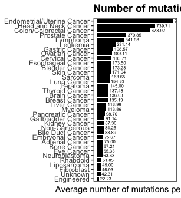

```r
  ggplot(data=normalized_mutations_cancer, aes(x = reorder(DISEASE, NORMALIZED_MUTATIONS), y = NORMALIZED_MUTATIONS)) +
  geom_bar(stat = "identity", fill = "black") +
  geom_text(aes(label = sprintf("%0.2f", round(NORMALIZED_MUTATIONS, digits =2))), size = 2, position = "dodge", hjust=-0.1) +
  xlab(NULL) +
  ylab("Average number of mutations per cell line") +
  ggtitle("Number of mutations in the splicing machinery") +
  theme_bw() +
  theme(axis.text.x = element_blank(),
        axis.ticks.x = element_blank(),
        legend.position = "none",
        plot.title = element_text(face = "bold"),
        panel.grid.major = element_blank(),
        panel.grid.minor = element_blank(),
        panel.background = element_blank(),
        ) +
  coord_flip()
```

```r
head(df_ccle_factors)
```

| DepMap_ID | Hugo_Symbol | cDNA_Change | primary_disease | Variant_Type | Annotation_Transcript | stripped_cell_line_name | Category | Complex | Consensus_group | Hotspot_LoF_cohorts | High_mutation_rate |
| --- | --- | --- | --- | --- | --- | --- | --- | --- | --- | --- | --- |
| ACH-000001 | SUGP1 | c.131G>A | Ovarian Cancer | SNP | ENST00000247001.5 | NIHOVCAR3 | core (HA) | A complex | A | NA | NA |
| ACH-000001 | SNRPB | c.303C>T | Ovarian Cancer | SNP | ENST00000381342.2 | NIHOVCAR3 | core (YC) | 17S U2 snRNP, A complex, B complex, Bact complex, C complex, U1 snRNP, U4/U6 snRNP, U5 snRNP, tri-snRNP, P complex | Sm | NA | NA |
| ACH-000001 | CWC27 | c.445A>G | Ovarian Cancer | SNP | ENST00000508024.1 | NIHOVCAR3 | core (YC) | Bact complex, C complex, P complex | B act | NA | NA |
| ACH-000001 | RBM3 | c.403T>C | Ovarian Cancer | SNP | ENST00000376759.3 | NIHOVCAR3 | other | NA | hnRNP | NA | NA |
| ACH-000001 | THOC2 | c.3656C>T | Ovarian Cancer | SNP | ENST00000245838.8 | NIHOVCAR3 | non-core | NA | EJC/TREX | NA | NA |
| ACH-000002 | CDK11A | c.2227C>T | Leukemia | SNP | ENST00000378633.1 | HL60 | core (HA) | NA | A | UCEC | UCEC |

Gene length for normalization

```r
gene_length = fread("gene_length.csv", select = c("Hugo_Symbol", "Transcript", "Length"))
```

Normalize mutations per transcript length

```r
normalized_mutations_gene =
  df_ccle_factors %>%
  group_by(Hugo_Symbol, Annotation_Transcript) %>%
  tally() %>%
  rename("MUTATIONS" = "n")

normalized_mutations_gene$Annotation_Transcript =
  gsub("\\..*", "", normalized_mutations_gene$Annotation_Transcript)

gene_length =
  gene_length %>%
  select(-Hugo_Symbol)

normalized_mutations_gene =
  normalized_mutations_gene %>%
  rename("Transcript" = "Annotation_Transcript") %>%
  left_join(gene_length, by = "Transcript") %>%
  #normalize by gene length
  mutate(NORMALIZED_MUTATIONS = MUTATIONS / Length) %>%
  arrange(desc(NORMALIZED_MUTATIONS)) %>%
  ungroup()

normalized_mutations_gene %>%
  top_n(20)
```

| Hugo_Symbol | Transcript | MUTATIONS | Length | NORMALIZED_MUTATIONS |
| --- | --- | --- | --- | --- |
| SF1 | ENST00000433274 | 3744 | 616 | 6.077922 |
| SF3B1 | ENST00000335508 | 8424 | 4315 | 1.952260 |
| HNRNPCL1 | ENST00000317869 | 2196 | 1172 | 1.873720 |
| PCBP1 | ENST00000303577 | 3096 | 1749 | 1.770154 |
| U2AF1 | ENST00000291552 | 1512 | 960 | 1.575000 |
| TCERG1 | ENST00000296702 | 6624 | 4220 | 1.569668 |
| DDX50 | ENST00000373585 | 3996 | 2552 | 1.565831 |
| TTC14 | ENST00000296015 | 4680 | 3044 | 1.537451 |
| SYNCRIP | ENST00000369622 | 4212 | 2943 | 1.431193 |
| DDX27 | ENST00000371764 | 3816 | 2714 | 1.406043 |

[output cut: 10 more lines]

Most mutated spliceosomal genes per cancer

```r
top_mutations_cancer =
  df_ccle_factors %>%
  select(Hugo_Symbol, primary_disease, Annotation_Transcript, DepMap_ID) %>%
  rename("Transcript" = "Annotation_Transcript") %>%
  group_by(Hugo_Symbol, Transcript) %>%
  count(primary_disease) %>%
  rename("MUTATIONS" = "n") %>%
  ungroup() %>%
  group_by(primary_disease) %>%
  arrange(desc(MUTATIONS)) %>%
  top_n(3)
head(top_mutations_cancer)
```

| Hugo_Symbol | Transcript | primary_disease | MUTATIONS |
| --- | --- | --- | --- |
| SPEN | ENST00000375759.3 | Colon/Colorectal Cancer | 2340 |
| ZMYM3 | ENST00000353904.2 | Head and Neck Cancer | 1836 |
| SF3B1 | ENST00000335508.6 | Head and Neck Cancer | 1800 |
| SPEN | ENST00000375759.3 | Endometrial/Uterine Cancer | 1404 |
| SPEN | ENST00000375759.3 | Leukemia | 1404 |
| SPEN | ENST00000375759.3 | Lung Cancer | 1368 |

```r
top_mutations_cancer$Transcript =
  gsub("\\..*", "", top_mutations_cancer$Transcript)

##FOR VISUALIZATION: NORMALIZE PER TRANSCRIPT LENGTH
#THERE IS NO LENGTH INFORMATION FOR ALL GENES
norm_top_mutations_cancer =
  top_mutations_cancer %>%
  left_join(gene_length, by ="Transcript") %>%
  mutate(NORM_MUTATIONS = MUTATIONS/Length)

head(norm_top_mutations_cancer)
```

| Hugo_Symbol | Transcript | primary_disease | MUTATIONS | Length | NORM_MUTATIONS |
| --- | --- | --- | --- | --- | --- |
| SPEN | ENST00000375759 | Colon/Colorectal Cancer | 2340 | 12242 | 0.1911452 |
| ZMYM3 | ENST00000353904 | Head and Neck Cancer | 1836 | 5542 | 0.3312883 |
| SF3B1 | ENST00000335508 | Head and Neck Cancer | 1800 | 4315 | 0.4171495 |
| SPEN | ENST00000375759 | Endometrial/Uterine Cancer | 1404 | 12242 | 0.1146871 |
| SPEN | ENST00000375759 | Leukemia | 1404 | 12242 | 0.1146871 |
| SPEN | ENST00000375759 | Lung Cancer | 1368 | 12242 | 0.1117464 |